# Worksheet 1 - Scientific Visualization MVE080/MMG640

## Basics in Python, Jupyter, plotnine and how to visualize amounts

Name: Anu Peter

This is the first worksheet in the course *Scientific Visualization*. This Jupyter notebook has three functions:

1. It describes the tasks.
2. It (sometimes) provides coding templates that you can use as a basis for your own code.
3. It is a template also for the report that you upload in Canvas.

The tasks are of various types: some are to read some text and then comment on it (no coding), and some are about creating visualizations using plotnine. Once you're finished with all the tasks, export this document as an HTML-file and upload it in Canvas. You are encouraged to discuss problems and solutions with your fellow students (in the class-room but also on CampusWire), but each student must solve all tasks by themselves and hand-in their own report. Notice that Jupyter notebooks use [Markdown](https://docs.github.com/en/github/writing-on-github/getting-started-with-writing-and-formatting-on-github/basic-writing-and-formatting-syntax#links) for writing text cells. Make sure you understand the basics. Later on you can also include $\LaTeX$ in your Markdown cells.

Throughout the assignment you shall use a Python workflow. If you are completely new to Python, take a look at this page. Python can do essentially all that MATLAB can, plus more. In this course we shall use Python in different contexts, starting with the [Jupyter Notebook interface](https://jupyter-notebook.readthedocs.io/en/stable/notebook.html).

Matrices and arrays are handled through the NumPy module. [Learn here](https://docs.scipy.org/doc/numpy/user/numpy-for-matlab-users.html) how NumPy is different from MATLAB.

The below loads the packages required for this homework.

```python
import numpy as np
import pandas as pd
from plotnine import *
# Currently in a plotine dependancy they have deprication warning, so
# we mute warnings to have a better experience
import warnings
warnings.filterwarnings("ignore")
import matplotlib.pyplot as plt
import seaborn as sns
# A nice color palette for categorical data
cbPalette = ["#E69F00", "#56B4E9", "#009E73",
             "#F0E442", "#0072B2", "#D55E00",
             "#CC79A7", "#999999"]
```

## Task 1

Read Chapter 1-3 of [Fundamentals of Data Visualizations](https://clauswilke.com/dataviz/), then answer the questions below.

### Question 1.1

Describe the visualization concept *scales*.

### Answer 1.1

Whenever we visualize data, we take data values and convert them in a systematic and logical way into the visual elements that make up the final graphic. Even though there are many different types of data visualizations, and on first glance a scatter plot, a pie chart, and a heatmap don’t seem to have much in common, all these visualizations can be described with a common language that captures how data values are turned into blobs of ink on paper or colored pixels on screen. The key insight is the following: All data visualizations map data values into quantifiable features of the resulting graphic. We refer to these features as aesthetics. To map data values onto aesthetics, we need to specify which data values correspond to which specific aesthetics values. This mapping between data values and aesthetics values is created via scales. A scale defines a unique one - one mapping between data and aesthetics If a scale isn’t one-to-one, then the data visualization becomes ambiguous.

### Question 1.2

In Figures 2.3 and 2.4 the same data is visualized in two different ways. Discuss the pros and cons of the two approaches. Which one do you prefer and why?

### Answer 1.2

Line graphs and heat maps are two different types of data visualizations that can be used to represent temperature data for four different places over the course of several months. Each has its own set of pros and cons:

#### line graph

Pros of line graph can be listed as(1)Clarity for Trends: Line graphs are excellent for showing trends over time. They make it easy to compare temperature variations over the months for different places. Viewers can quickly identify temperature fluctuations and patterns.(2)Individual Place Comparison: You can represent each place with a different colored line, allowing for straightforward visual comparison of temperature variations between the four locations. Cons:Limited Space: In a line graph, you might run out of space if you have many months or places to represent, making it less suitable for displaying extensive datasets.

#### Heat Map:

Pros:(1)Visual Overview: Heat maps provide a high-level visual overview of temperature patterns. They can quickly convey which months are warmer or cooler across the four places.(2)Color-Based Comparison: Colors can be used to represent temperature ranges, making it easy to compare temperature patterns visually. Viewers can quickly identify hotter and colder months across different places.(3)Compact Representation: Heat maps are space-efficient and can represent data for many months and locations in a relatively compact format. Cons:(1)Loss of Precision: Heat maps do not provide precise temperature values for individual months or places, so if precise values are crucial, they may not be the best choice.(2)Difficulty in Identifying Exact Values: It can be challenging to determine exact temperature values from a heat map, especially if the color scale is not clearly defined.(3)Less Suitable for Trends: Heat maps are not as effective as line graphs at showing trends over time, as they emphasize relative comparisons more than precise values. (4)Limited Annotative Capability: Heat maps may not provide much room for annotations or labels to explain specific temperature events or details.

In summary, the choice between a line graph and a heat map depends on your specific goals and the audience's needs. Line graphs are better for showing precise data and trends, while heat maps are more suitable for providing a visual overview of temperature patterns and comparisons. It's also possible to use both types of visualizations together to provide a comprehensive representation of the data.

### Question 1.3

Describe situations when *nonlinear axes* might be useful. When should they not be used?

### Answer 1.3

Nonlinear axes can be valuable tools for specific types of data, such as exponential or highly skewed datasets, where they can enhance visualization and interpretation. However, they should be used cautiously, with clear explanations and proper labeling, to avoid misinterpretation and ensure that the audience understands the scale transformation applied to the data.

### Situations when Nonlinear Axes Might be Useful:

Exponential Data, Large Range of Values, Skewed Distributions, Multiplicative Processes.

### Situations when Nonlinear Axes Should Not be Used:

Misleading Interpretation: Commonplace Data, Data Manipulation, Comparative Analysis.

### Question 1.4

In which situations could a *polar coordinate system* be useful?

### Answer 1.4

The polar coordinate system, we specify positions via an angle and a radial distance from the origin, and therefore the angle axis is circular Polar coordinates can be useful for data of a periodic nature, in the context of geospatial data, i.e., maps. Locations on the globe are specified by their longitude and latitude,Cyclical DataDirectional Data: For data that has directional components, such as wind patterns, compass data, or star positions in astronomy, a polar coordinate system provides an intuitive way to display and analyze these directional relationships. It allows you to visualize angles and magnitudes effectively,Circular Spatial Data,Relationships in 360 Degrees,Comparing Multiple Cycles,Emphasizing Relative Proportions,Aesthetic and Design Choices.

## Task 2 - Tidy data, ggplot and distributions

Several graphics libraries such as ggplot2 and plotnine are at their best when the provided data is tidy. However, data is often not provided in a tidy format, hence being able to transform non-tidy data into tidy data is a crucial skill.

### Question 2.1

In the lecture I provided a small non-tidy dataset (code below).

```python
data1 = pd.DataFrame({"Site" : ["Stockholm", "Gothenburg", "London"],
                      "1999" : [13, 85, 77],
                      "2000" : [21, 31, 15]})
data1
```

|  | Site | 1999 | 2000 |
| --- | --- | --- | --- |
| 0 | Stockholm | 13 | 21 |
| 1 | Gothenburg | 85 | 31 |
| 2 | London | 77 | 15 |

Transform this small dataset into a tidy dataset. Print the table below (as I did above).

*Hint* [melt](https://pandas.pydata.org/docs/reference/api/pandas.melt.html)

```python
# Use the 'pd.melt()' function to reshape the data into a tidy format
tidy_data1 = data1.melt(id_vars=['Site'], var_name='Year', value_name='Value')

# Display the resulting tidy data
tidy_data1
```

|  | Site | Year | Value |
| --- | --- | --- | --- |
| 0 | Stockholm | 1999 | 13 |
| 1 | Gothenburg | 1999 | 85 |
| 2 | London | 1999 | 77 |
| 3 | Stockholm | 2000 | 21 |
| 4 | Gothenburg | 2000 | 31 |
| 5 | London | 2000 | 15 |

### Question 2.2

Datasets are often bigger than above. I have made a subset of the weather data used in the lecture non-tidy (available on the webpage).

Transform this dataset into a tidy dataset. Print the table below (as I did above)

```python
weather_not_tidy=pd.read_csv('/content/Weather_not_tidy.csv')
weather_tidy = pd.melt(weather_not_tidy, id_vars=['month','day','hour_of_day'], value_vars= ['Temp2009', 'Temp2010'], var_name='year', value_name='temperature')
weather_tidy['year'] = weather_tidy['year'].replace({'Temp2009':'2009'})
weather_tidy['year'] = weather_tidy['year'].replace({'Temp2010':'2010'})
weather_tidy = weather_tidy[['year', 'month', 'day', 'hour_of_day', 'temperature']]

weather_tidy
```

|  | year | month | day | hour_of_day | temperature |
| --- | --- | --- | --- | --- | --- |
| 0 | 2009 | Jan | 1 | 12 | -0.9 |
| 1 | 2009 | Jan | 2 | 12 | -2.2 |
| 2 | 2009 | Jan | 3 | 12 | 4.2 |
| 3 | 2009 | Jan | 4 | 12 | -4.7 |
| 4 | 2009 | Jan | 5 | 12 | -7.8 |
| ... | ... | ... | ... | ... | ... |
| 725 | 2010 | Dec | 27 | 12 | -6.8 |
| 726 | 2010 | Dec | 28 | 12 | -11.0 |
| 727 | 2010 | Dec | 29 | 12 | -10.6 |
| 728 | 2010 | Dec | 30 | 12 | -3.0 |
| 729 | 2010 | Dec | 31 | 12 | -2.7 |

730 rows × 5 columns

## Distributions

For this part reading Chapter 7 and 9 in [Fundamentals of Data Visualizations](https://clauswilke.com/dataviz/) helps.

## Question 3.1

The benefit with tidy data is that it is easy to work with. For this task use the tidy weather dataset from above and choose three months and by **a density and histogram plot** visualize the differences in temperature between 2009 and 2010 for the chosen months in a readable manner. Make sure to print the visuals below.

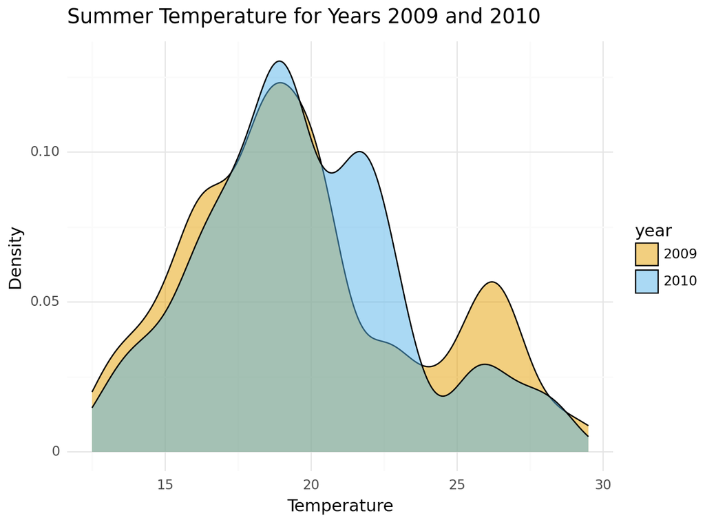

```python
data_summer = weather_tidy.query("(month == 'Jun' or month == 'Jul' or month == 'Aug') and (year == '2010' or year == '2009')")

data_summer = data_summer.assign(year= pd.Categorical(data_summer["year"]))
p1 = (ggplot(data_summer, aes("temperature", fill = "year"))
      + geom_density(aes(fill = "year"), alpha=0.5, bw=0.8)
      + scale_fill_manual(values=cbPalette, name="year")
      + labs(x="Temperature", y="Density", title="Summer Temperature for Years 2009 and 2010")
      + theme_minimal())
print(p1)
```

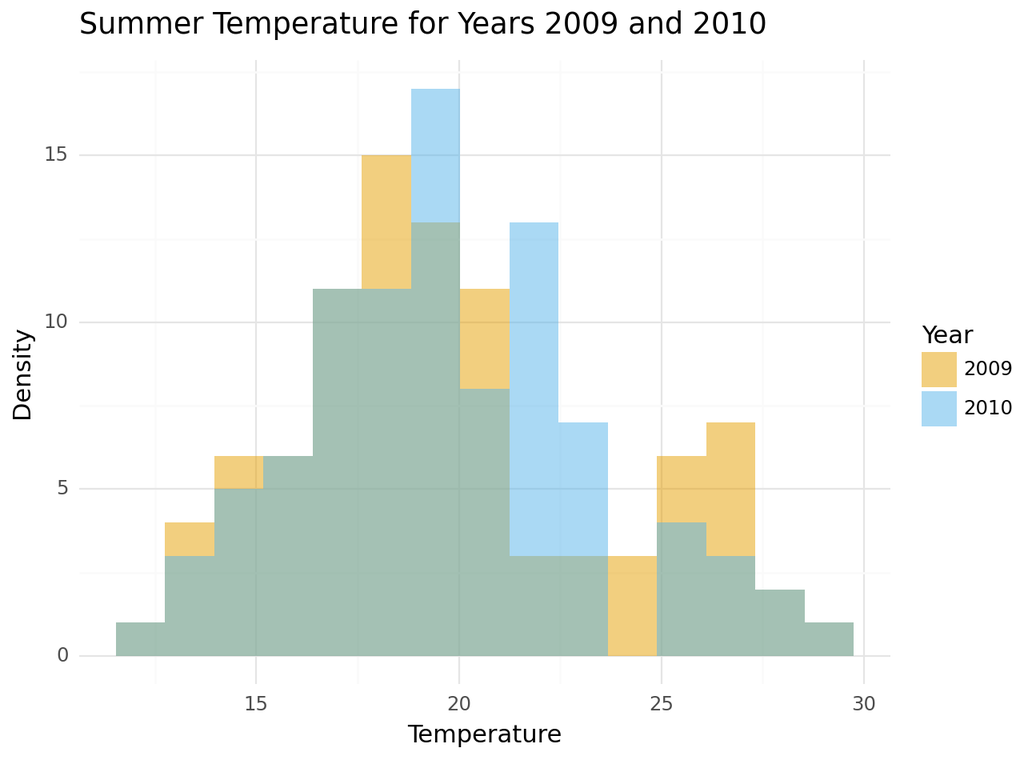

```
<Figure Size: (640 x 480)>
```

```python
p2 = (ggplot(data_summer, aes("temperature", fill = "year")) #x-axis = temperature, fill color = year
    + geom_histogram(bins=15, alpha=0.5, position = "identity") #histogram: number of bins, transparency, position
    + scale_fill_manual(values=cbPalette, name = "Year") #sets the fill color manually using a color palette.
    + labs(x="Temperature", y="Density", title="Summer Temperature for Years 2009 and 2010")
    + theme_minimal())
p2
```

Density Plot is useful for showing the distribution of temperature differences and it can provide a smoother representation of the data. Especially helpful when dealing with a relatively small dataset .But Histogram provides a more granular view of the frequency distribution.It is well-suited for larger datasets as it divides the data into discrete bins also,useful for identifying specific temperature ranges that are more common. In summary, for this context I prefer histogram.

### Question 3.2

In Lecture2 I used boxplots, error-bars, and violin plots to visualize fluctuations in winter temperature in Västerås. Now using the weather data above plot the temperature per month (like in Fig. 9.8 [here](https://clauswilke.com/dataviz/boxplots-violins.html)) using error-bars, boxplots and violin plots with data points. For each month plot the temperature for 2009 and 2010 next to each other (see example on webpage).

```python
weather_tidy['mean_temp'] = weather_tidy.groupby(['month', 'year'])['temperature'].transform('mean')
weather_tidy['std_temp'] = weather_tidy.groupby(['month', 'year'])['temperature'].transform('std')
```

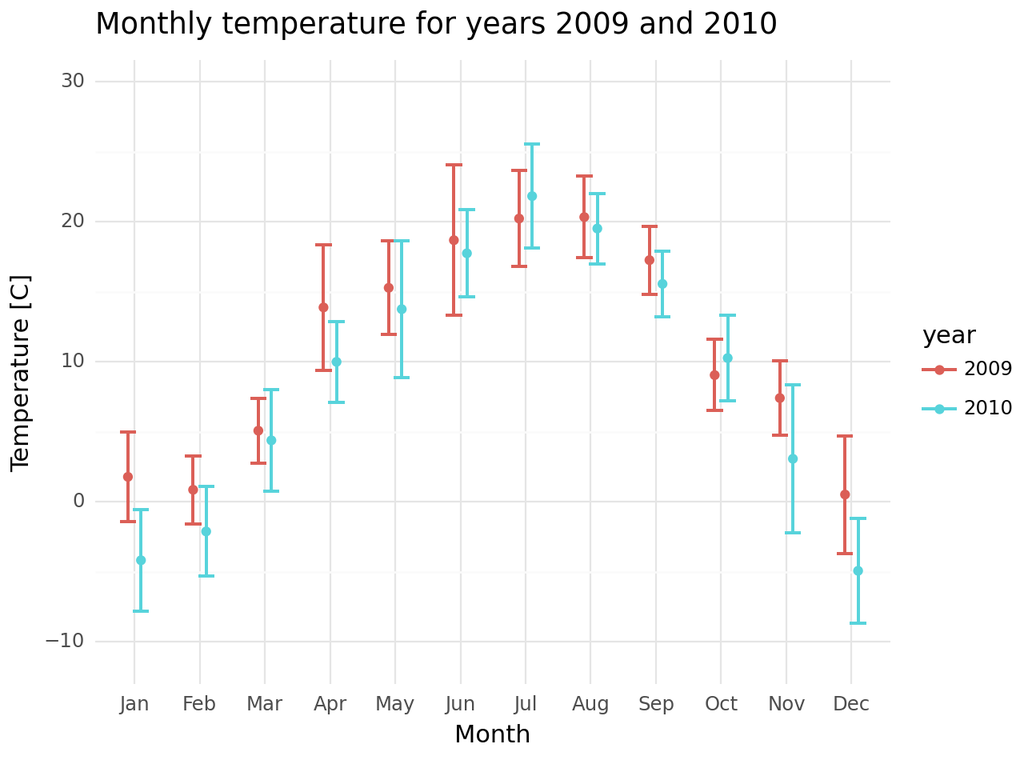

```
<Figure Size: (640 x 480)>
```

```python
data_weather = weather_tidy.assign(year=pd.Categorical(weather_tidy["year"]))

month_order = ["Jan", "Feb", "Mar", "Apr", "May", "Jun", "Jul", "Aug", "Sep", "Oct", "Nov", "Dec"]

# Convert the "month" column to a categorical variable with the correct order
data_weather['month'] = pd.Categorical(data_weather['month'], categories=month_order, ordered=True)

# Group by month and year to get mean temperature
mean_data = data_weather.groupby(['month', 'year'], as_index=False)['temperature'].mean()

p = (
    ggplot(data_weather, aes(x='month', y='temperature', color='year'))
    + geom_errorbar(
        aes(ymin='mean_temp - std_temp', ymax='mean_temp + std_temp'),
        position=position_dodge(width=0.4)
    )
    + geom_point(
        mean_data, aes(x='month', y='temperature', color='year'),
        position=position_dodge(width=0.4), size=1.5
    )
    + labs(y = "Temperature [C]", x="Month", title="Monthly temperature for years 2009 and 2010")
    + theme_minimal()
)

p
```

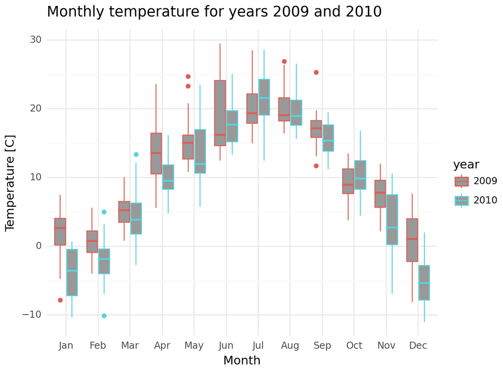

```
<Figure Size: (640 x 480)>
```

```python
p = (ggplot(data_weather, aes('month', 'temperature', color='year'))
    + geom_boxplot(fill = cbPalette[7])
    + labs(y = "Temperature [C]", x="Month", title="Monthly temperature for years 2009 and 2010")
    + theme_minimal())

p
```

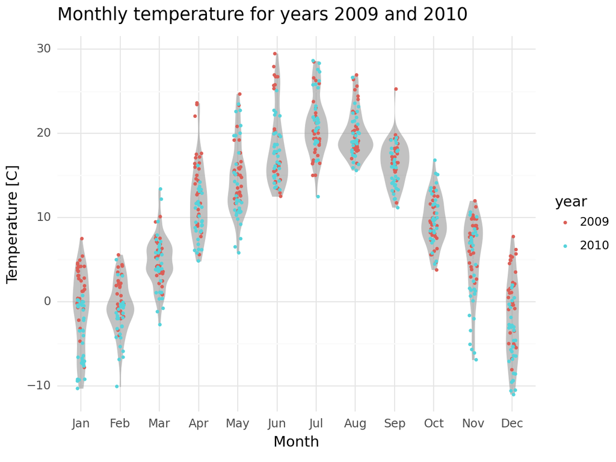

```
<Figure Size: (640 x 480)>
```

```python
p1 = (ggplot(data_weather, aes('month', 'temperature', color='year'))
    + geom_violin(fill = cbPalette[7], alpha=0.6, color=None)
    + geom_jitter(width=0.1, size=0.5)
    + labs(y = "Temperature [C]", x="Month", title="Monthly temperature for years 2009 and 2010")
    + theme_minimal())
p1
```

Briefly discuss the drawback with each approach (standard errors, boxplots, and violin plots).

### Boxplot:

Drawback: Boxplots provide a summary of the distribution but may not capture the full shape of the data. They can hide details about the distribution, especially in the tails. Outliers may also be displayed as individual points, making them easily overlooked.

### Violin Plot:

One of the drawbacks with a violin plot is that it can be hard to read summary statistics from it. Produce a violin plot visual here, where you have also drawn the median for each violin, as well as the data points.

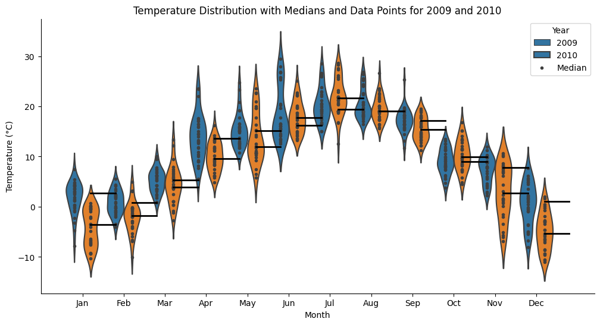

```python
import matplotlib.pyplot as plt
import seaborn as sns

# Assuming you have loaded your data and structured it appropriately

# Filter the data for the years 2009 and 2010
filtered_data = weather_tidy_data[weather_tidy_data['year'].isin(['Temp2009', 'Temp2010'])]

# Create a violin plot with medians and data points
plt.figure(figsize=(12, 6))
sns.violinplot(x='month', y='Temprature', hue='year', data=filtered_data, inner='points', scale='width')

# Add median lines
medians = filtered_data.groupby(['month', 'year'])['Temprature'].median().reset_index()
for i, month in enumerate(filtered_data['month'].unique()):
    for year in ['Temp2009', 'Temp2010']:
        median_val = medians[(medians['month'] == month) & (medians['year'] == year)]['Temprature'].values[0]
        plt.plot([i + 0.2, i + 0.8], [median_val, median_val], color='black', linewidth=2)

# Add legend
plt.legend(title='Year', labels=['2009', '2010', 'Median'])

sns.despine()
plt.title('Temperature Distribution with Medians and Data Points for 2009 and 2010')
plt.xlabel('Month')
plt.ylabel('Temperature (°C)')

# Show the plot
plt.show()
```

Briefly discuss how you could make it easy for the reader to understand that the line the visual represent the median.

### Question 3.3

Some people argue that visuals should be as minimal as possible. On the webpage you have a bad example of a minimalist way to plot the min, median, and max temperature of each month in 2009 and 2010 using the dataset in Question 3.2 (where you hopefully have filtered out daily temperatures for 2009 and 2010). By **only** using geom_point recreate the visual (you do not need to recreate the title). **You are not allowed to transform the dataset**.

*Hint - Remember the stat argument in ggplot*

[figure not shown]

```python
# Insert code here library(ggplot2)

from plotnine import ggplot, aes, geom_point, theme_minimal, labs

# Assuming your filtered data is stored in a DataFrame named 'weather_data'
# Make sure your DataFrame has columns: 'year', 'month', and 'Temperature'

# Calculate the minimum, median, and maximum values for each month and year
summary_data = weather_tidy_data.groupby(['year', 'month'])['Temprature'].agg(['min', 'median', 'max']).reset_index()

# Create the minimalistic visual
plot = (ggplot(summary_data, aes(x='month')) +
        geom_point(aes(y='min', color='year'), size=2) +
        geom_point(aes(y='median', color='year'), size=2) +
        geom_point(aes(y='max', color='year'), size=2) +
        labs(x='Month', y='Temperature') +
        theme_minimal()
       )

print(plot)




# Remember to print the visual
```

### Question 3.4

Using the full weather dataset on the webpage create two plots of your on choice. For example, you can compare winter temperatures across years, differences in night and day temperatures etc. For each visual provide a brief motivation on why your choice of visual (e.g violin or boxplot) is a good choice.

```python
data1=pd.read_csv('/content/Weather_tidy_full .csv')
data1
```

|  | year | month | day | Temperature | hour_of_day |
| --- | --- | --- | --- | --- | --- |
| 0 | 1961 | Jan | 1 | 0.8 | 6.0 |
| 1 | 1961 | Jan | 1 | 1.0 | 12.0 |
| 2 | 1961 | Jan | 1 | 1.4 | 18.0 |
| 3 | 1961 | Jan | 2 | 1.8 | 6.0 |
| 4 | 1961 | Jan | 2 | 2.2 | 12.0 |
| ... | ... | ... | ... | ... | ... |
| 224938 | 2013 | Aug | 24 | 19.3 | 9.0 |
| 224939 | 2013 | Aug | 24 | 19.1 | 10.0 |
| 224940 | 2013 | Aug | 24 | 20.5 | 11.0 |
| 224941 | 2013 | Aug | 24 | 21.0 | 12.0 |
| 224942 | 2013 | Aug | 24 | 2.0 | NaN |

224943 rows × 5 columns

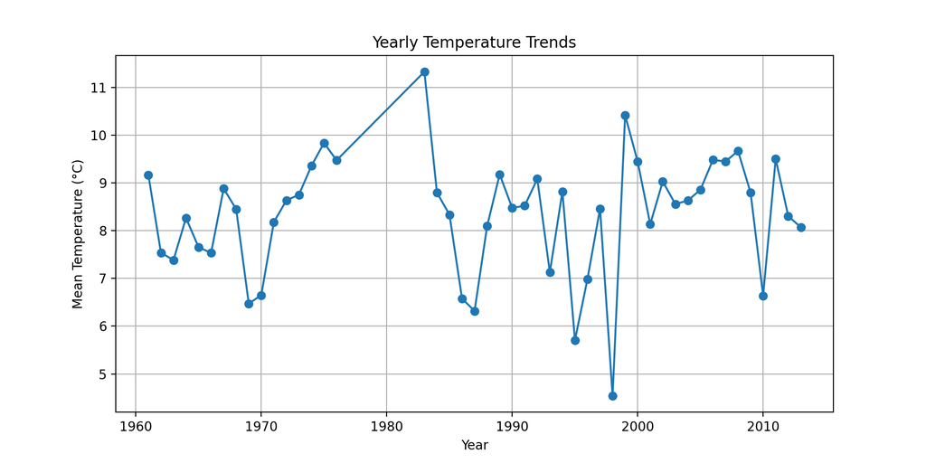

```python
# Insert code here data1=pd.read_csv('Weather_tidy_full.csv')
# Group data by year and calculate the mean temperature for each year
yearly_mean_temp = data1.groupby('year')['Temperature'].mean()

# Create a line plot
plt.figure(figsize=(10, 5))
plt.plot(yearly_mean_temp.index, yearly_mean_temp.values, marker='o', linestyle='-')
plt.xlabel('Year')
plt.ylabel('Mean Temperature (°C)')
plt.title('Yearly Temperature Trends')
plt.grid(True)
plt.show()

# Remember to print the visual
```

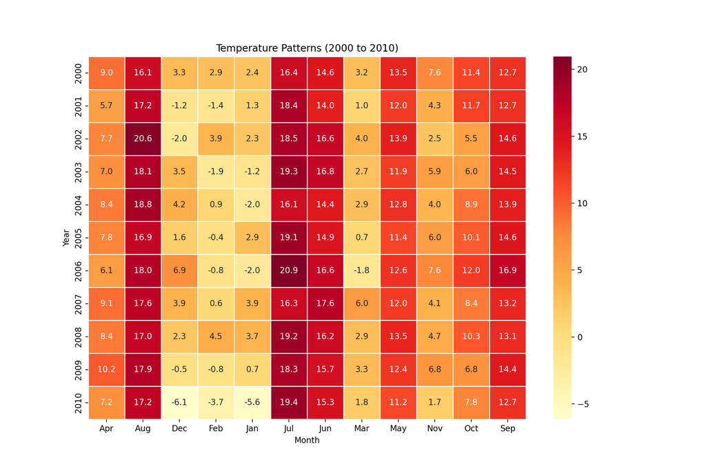

```python
# Insert code here


# Filter the data for the years 1989 to 2020
filtered_data = data1[(data1['year'] >= 2000) & (data1['year'] <= 2010)]

# Pivot the data to create a matrix of temperature values
heatmap_data = filtered_data.pivot_table(index='year', columns='month', values='Temperature')

# Create the heatmap
plt.figure(figsize=(12, 8))
sns.heatmap(heatmap_data, cmap='YlOrRd', annot=True, fmt=".1f", linewidths=0.5)
plt.title('Temperature Patterns (2000 to 2010)')
plt.xlabel('Month')
plt.ylabel('Year')
plt.show()

# Remember to print the visual
```

## Amounts

For this part reading Chapter 6 in [Fundamentals of Data Visualizations](https://clauswilke.com/dataviz/) can help.

### Question 4.1

Barplots are the workhorse for plotting amounts. Create a dataframe with the values from Tab. 6.1 in the [course book](https://clauswilke.com/dataviz/visualizing-amounts.html), and recreate Fig. 6.1 and Fig. 6.3 in the course book.

```python
import os

# Create the 'Figs' directory if it doesn't exist
if not os.path.exists("Figs"):
    os.makedirs("Figs")
print(os.getcwd())
```

```
/content
```

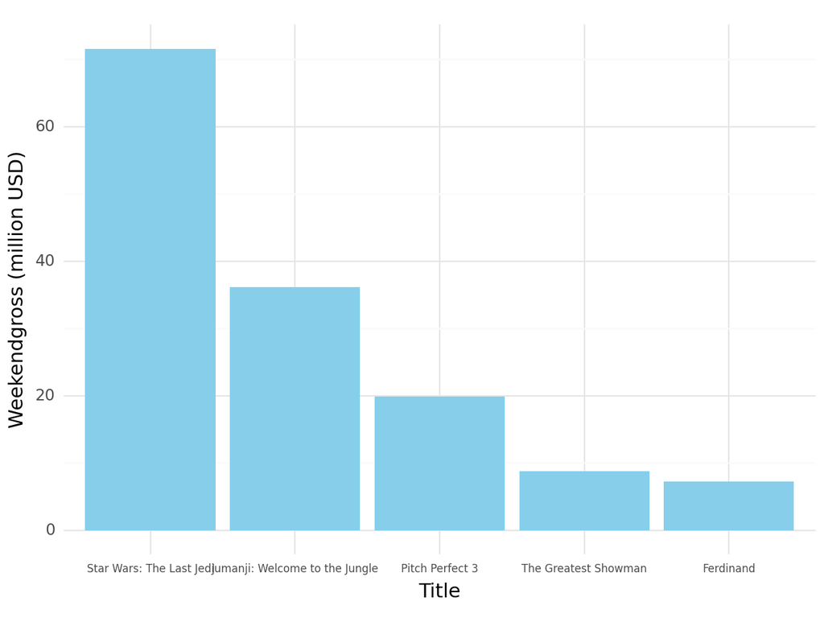

```
<Figure Size: (640 x 480)>
```

```python
from plotnine import ggplot, aes, geom_bar, labs, theme_minimal, theme, element_text
import pandas as pd
import os

data = pd.DataFrame({
    'Rank': [1, 2, 3, 4, 5],
    'Title': ['Star Wars: The Last Jedi', 'Jumanji: Welcome to the Jungle', 'Pitch Perfect 3', 'The Greatest Showman', 'Ferdinand'],
    'Weekendgross': [71565498, 36169328, 19928525, 8805843, 7316746]
})

pos = data["Title"].values[np.argsort(data["Weekendgross"])]

BASE_WIDTH = 8  # Width in inches
BASE_HEIGHT = 6  # Height in inches

# Create the 'Figs' directory if it doesn't exist
if not os.path.exists("Figs"):
    os.makedirs("Figs")

p = (ggplot(data, aes(x='Title', y='Weekendgross/1000000'))
     + geom_bar(stat="identity", fill="#87CEEB")
     + labs(x="Title", y='Weekendgross (million USD)', title="")
     + scale_x_discrete(limits=pos[::-1])
     + theme_minimal()
     + theme(legend_position="none",
             axis_text_x=element_text(size=6, angle=0, hjust=1.5))  # Adjust size and angle here
)

p.save("Figs/Fix1.png", width=BASE_WIDTH, height=BASE_HEIGHT, dpi=300)
p
```

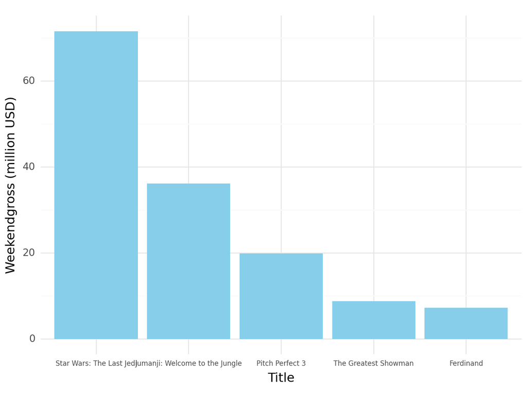

```
<Figure Size: (640 x 480)>
```

```python
# Insert code here for Fig. 6.1
from plotnine import ggplot, aes, geom_bar, labs, theme_minimal, theme, element_text

data = pd.DataFrame({
    'Rank': [1, 2, 3, 4, 5],
    'Title': ['Star Wars: The Last Jedi', 'Jumanji: Welcome to the Jungle', 'Pitch Perfect 3', 'The Greatest Showman', 'Ferdinand'],
    'Weekendgross': [71565498, 36169328, 19928525, 8805843, 7316746]
})

pos = data["Title"].values[np.argsort(data["Weekendgross"])]

BASE_WIDTH = 8  # Width in inches
BASE_HEIGHT = 6  # Height in inches

p = (ggplot(data, aes(x='Title', y='Weekendgross/1000000'))
  + geom_bar(stat="identity", fill="#87CEEB")
  + labs(x="Title", y='Weekendgross (million USD)', title="")
  + scale_x_discrete(limits=pos[::-1])
  + theme_minimal()
  + theme(legend_position="none",
          axis_text_x=element_text(size=6, angle=0, hjust=1.5))  # Adjust size and angle here
)

p.save("Figs/Fix1.png", width=BASE_WIDTH, height=BASE_HEIGHT, dpi=300)
p

# Remember to print the visual
```

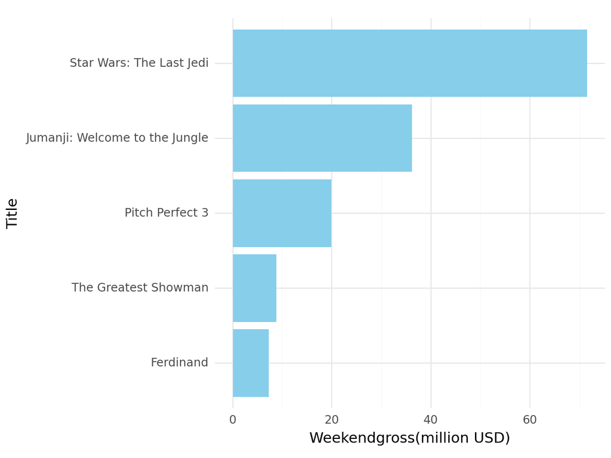

```
<Figure Size: (640 x 480)>
```

```python
# Insert code here for Fig. 6.2
p1= (ggplot(data, aes(x='Title', y='Weekendgross/1000000'))
  + geom_bar(stat="identity", fill="#87CEEB")
  + labs(x = "Title", y = 'Weekendgross(million USD)', title = "")
  + scale_x_discrete(limits=pos)
  + coord_flip()
  + theme_minimal()
  + theme(axis_text_x = element_text(angle = 0 , hjust=0.1),
          legend_position="none"))

p1.save("Figs/Fix1.png", width=BASE_WIDTH, height=BASE_HEIGHT, dpi=300)
p1
# Remember to print the visual
```

### Question 4.2

Often we want to highlight a specific column in a barplot. Using the same layout as in the most recent plot highlight the column of Jumanji in orange, and keep the remaining columns grey.

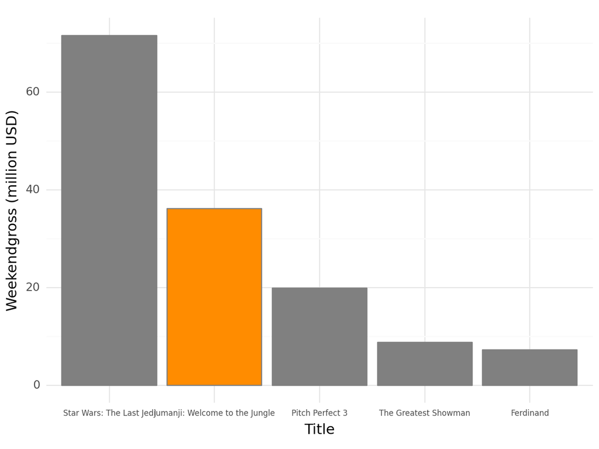

```
<Figure Size: (640 x 480)>
```

```python
col_use = ["#808080"]
highlight_color = "#FF8C00"
BASE_WIDTH = 8  # Width in inches
BASE_HEIGHT = 6  # Height in inches

p2 = (ggplot(data, aes(x='Title', y='Weekendgross/1000000'))
  + geom_bar(stat="identity", fill="#87CEEB")  + geom_bar(aes(fill='Title'), stat="identity", position="dodge", color="grey")
   + scale_fill_manual(values=[highlight_color if title == 'Jumanji: Welcome to the Jungle' else col_use[0] for title in data['Title']])
  + labs(x="Title", y='Weekendgross (million USD)', title="")
  + scale_x_discrete(limits=pos[::-1])
  + theme_minimal()
  + theme(legend_position="none",
          axis_text_x=element_text(size=6, angle=0, hjust=1.5))  # Adjust size and angle here
)

p2.save("Figs/Fix1.png", width=BASE_WIDTH, height=BASE_HEIGHT, dpi=300)
p2
# Remember to print the visual
```

Besides using colors to highlight, adding numbers for the highlighted category can also help. For the Jumanji column also add the number that the bar corresponds to.

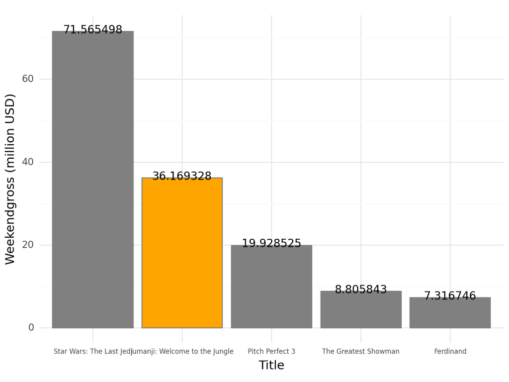

```
<Figure Size: (640 x 480)>
```

```python
highlight_color = "orange"  # Specify the color you want to use for highlighting
p3 = (ggplot(data, aes(x='Title', y='Weekendgross/1000000'))
    + geom_bar(stat="identity", fill="#87CEEB")
    + geom_bar(aes(fill='Title'), stat="identity", position="dodge", color="grey")
    + geom_text(aes(label='Weekendgross/1000000'), size=10, nudge_y=0.3, position=position_dodge(width=0.9), color='black')
    + scale_fill_manual(values=[highlight_color if title == 'Jumanji: Welcome to the Jungle' else col_use[0] for title in data['Title']])
    + labs(x="Title", y='Weekendgross (million USD)', title="")
    + scale_x_discrete(limits=pos[::-1])
    + theme_minimal()
    + theme(legend_position="none",
            axis_text_x=element_text(size=6, angle=0, hjust=1.5))  # Adjust size and angle here
)

p3.save("Figs/Fix1.png", width=BASE_WIDTH, height=BASE_HEIGHT, dpi=300)
p3
```

### Question 4.3

On the webpage I have uploaded a dataset on the number of marriages in Stockholm, Gothenburg, Malmo and rest of Sweden for 2020, 2015, 2010 and 2005. Using this dataset produce i) a visual where it is easy to see which year Stockholm had the second most marriages, and ii) a visual where it is easy to see how many more marriages there was in Stockholm compared to Gothenburg in 2015. **In each visual I want you to include the number of marriages for each city and year**.

```python
data3 = pd.read_csv("Marriage.csv")
data3
```

|  | region | number_marriges | year |
| --- | --- | --- | --- |
| 0 | Stockholm | 949 | 2020 |
| 1 | Gothenburg | 481 | 2020 |
| 2 | Malmo | 297 | 2020 |
| 3 | Rest_of_sweden | 2359 | 2020 |
| 4 | Stockholm | 1960 | 2015 |
| 5 | Gothenburg | 681 | 2015 |
| 6 | Malmo | 467 | 2015 |
| 7 | Rest_of_sweden | 3603 | 2015 |
| 8 | Stockholm | 1995 | 2010 |
| 9 | Gothenburg | 710 | 2010 |
| 10 | Malmo | 430 | 2010 |
| 11 | Rest_of_sweden | 3634 | 2010 |
| 12 | Stockholm | 1558 | 2005 |
| 13 | Gothenburg | 611 | 2005 |
| 14 | Malmo | 395 | 2005 |
| 15 | Rest_of_sweden | 3221 | 2005 |

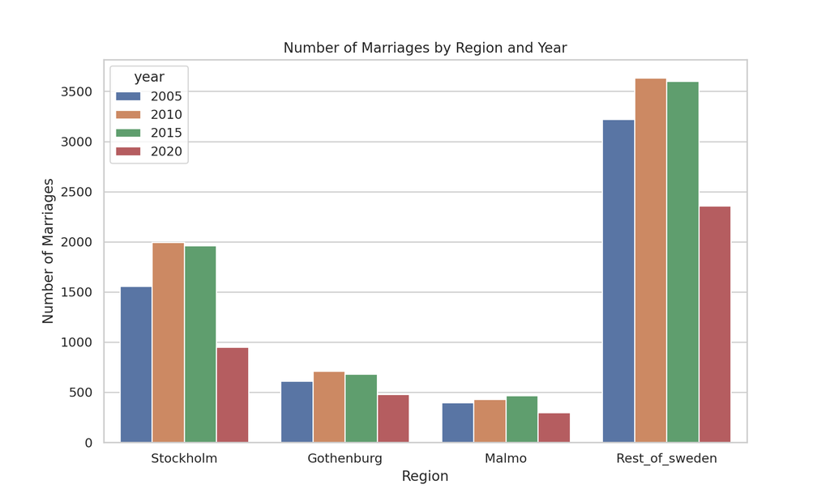

```python
import pandas as pd
import seaborn as sns
import matplotlib.pyplot as plt

# Your data
data = {
    'region': ['Stockholm', 'Gothenburg', 'Malmo', 'Rest_of_sweden', 'Stockholm', 'Gothenburg', 'Malmo', 'Rest_of_sweden',
               'Stockholm', 'Gothenburg', 'Malmo', 'Rest_of_sweden', 'Stockholm', 'Gothenburg', 'Malmo', 'Rest_of_sweden'],
    'number_marriages': [949, 481, 297, 2359, 1960, 681, 467, 3603, 1995, 710, 430, 3634, 1558, 611, 395, 3221],
    'year': [2020, 2020, 2020, 2020, 2015, 2015, 2015, 2015, 2010, 2010, 2010, 2010, 2005, 2005, 2005, 2005]
}

df = pd.DataFrame(data)

# Set the style for the plot
sns.set(style="whitegrid")

# Create a bar plot
plt.figure(figsize=(10, 6))
sns.barplot(x='region', y='number_marriages', hue='year', data=df)
plt.title('Number of Marriages by Region and Year')
plt.xlabel('Region')
plt.ylabel('Number of Marriages')
plt.show()
```

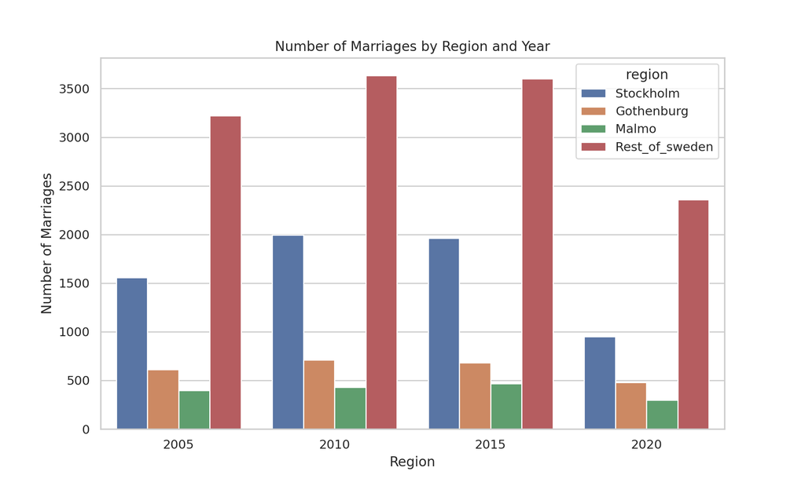

```python
import pandas as pd
import seaborn as sns
import matplotlib.pyplot as plt

# Your data
data = {
    'region': ['Stockholm', 'Gothenburg', 'Malmo', 'Rest_of_sweden', 'Stockholm', 'Gothenburg', 'Malmo', 'Rest_of_sweden',
               'Stockholm', 'Gothenburg', 'Malmo', 'Rest_of_sweden', 'Stockholm', 'Gothenburg', 'Malmo', 'Rest_of_sweden'],
    'number_marriages': [949, 481, 297, 2359, 1960, 681, 467, 3603, 1995, 710, 430, 3634, 1558, 611, 395, 3221],
    'year': [2020, 2020, 2020, 2020, 2015, 2015, 2015, 2015, 2010, 2010, 2010, 2010, 2005, 2005, 2005, 2005]
}

df = pd.DataFrame(data)

# Set the style for the plot
sns.set(style="whitegrid")

# Create a bar plot
plt.figure(figsize=(10, 6))
sns.barplot(x='year', y='number_marriages', hue='region', data=df)
plt.title('Number of Marriages by Region and Year')
plt.xlabel('Region')
plt.ylabel('Number of Marriages')
plt.show()
```

### Question 4.4

When plotting the mobile operating system data in the lectures I used a classical barplot. Another way which makes it easy to track the trend over several years or across companies is a common line-plot. Using the dataset on the webpage recreate the present on the webpage.

```python
df=pd.read_csv('/content/mobile.csv')
df
```

|  | Year | OperatingSystem | Share |
| --- | --- | --- | --- |
| 0 | 2009 | iOS | 59.35 |
| 1 | 2009 | Android | 5.58 |
| 2 | 2009 | BlackBerry OS | 14.42 |
| 3 | 2009 | Windows | 2.91 |
| 4 | 2009 | SymbianOS | 2.50 |
| ... | ... | ... | ... |
| 59 | 2016 | Windows | 0.91 |
| 60 | 2016 | SymbianOS | 0.01 |
| 61 | 2016 | Playstation | 0.05 |
| 62 | 2016 | Other | 0.25 |
| 63 | 2016 | Unknown | 0.21 |

64 rows × 3 columns

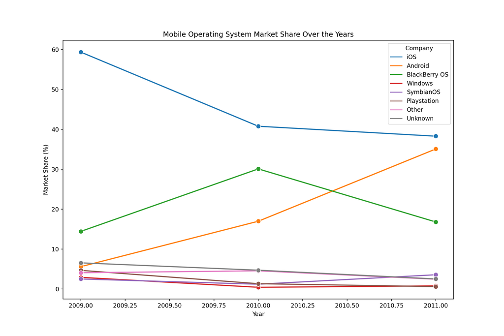

```python
df=pd.read_csv('mobile.csv')
fd= df[df['Year'].isin([2009, 2010, 2011])]

# Create a line plot
plt.figure(figsize=(12, 8))
sns.lineplot(x='Year', y='Share', hue='OperatingSystem', data=fd, marker='o', markersize=8, linewidth=2)

# Add labels and title
plt.title('Mobile Operating System Market Share Over the Years')
plt.xlabel('Year')
plt.ylabel('Market Share (%)')

# Show legend
plt.legend(title='Company', loc='best')

# Show the plot
plt.show()

# Remember to print the visual
```

By default plotnine places the legend for a visual to the right, or bottom depending on a theme. Do you think having a legend next to the visual is the best solution?

The best placement for a legend in a plot depends on the specific context and the nature of the data. It's important to consider factors such as the layout of your plot, the amount of data, and the overall design goals. Ultimately, the decision on legend placement should be based on what enhances the clarity and interpretability of the visual for your audience.In this context having legend next to visual is beneficial so that readers can understand abbout operating system at first glance itself.

### Question 4.5

In the lecture I provided data on European nations median lifespan. Now using the full dataset (on the webpage) provided on the webpage select a subset of countries and visualize i) life-expectancy across a timespan of your choice and ii) life expectancy in 2020. Provide a brief motivation for your choice of visual - and why your choice is readable.

# line plot

A line plot is a powerful and clear visualization choice for displaying the evolution of life expectancy over time, especially when dealing with a time series dataset involving multiple countries.

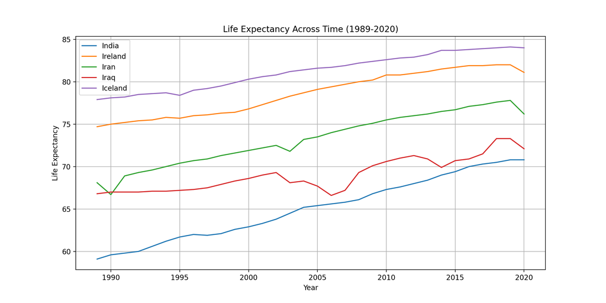

```python
data4 = pd.read_csv("Life_tidy_full.csv")
# Select a subset of countries (you can replace this list with the countries you're interested in)
selected_countries = [ 'India', 'Ireland', 'Iran', 'Iraq', 'Iceland']

# Filter data for the selected countries
subset_data = data4[data4["country"].isin(selected_countries)]

# Filter the dataset for the selected countries and the time span 1989 to 2020
subset_data1 = subset_data[(subset_data['Year'] >= 1989) & (subset_data['Year'] <= 2020) & (subset_data['country'].isin(selected_countries))]

# Create a line plot for life expectancy across the selected time span
plt.figure(figsize=(12, 6))
for country in selected_countries:
    country_data = subset_data1[subset_data1['country'] == country]
    plt.plot(country_data['Year'], country_data['Life_expactancy'], label=country)

plt.xlabel('Year')
plt.ylabel('Life Expectancy')
plt.title('Life Expectancy Across Time (1989-2020)')
plt.legend()
plt.grid(True)

plt.show()
```

### Bar plots

Bar plots are suitable for showing and comparing values of different categories or groups. In this case, we are comparing the life expectancy of different countries in the year 2020.

Clarity of comparison: Bar plots make it easy to compare values across different categories (countries in this case) at a glance. Each bar represents a country's life expectancy, and the lengths of the bars make comparisons straightforward.

Readability: Bar plots are generally easy to read and interpret, making them suitable for conveying information to a wide audience.

Emphasis on individual values: The use of text labels on top of each bar emphasizes the specific life expectancy values, providing additional information without the need for a separate legend.

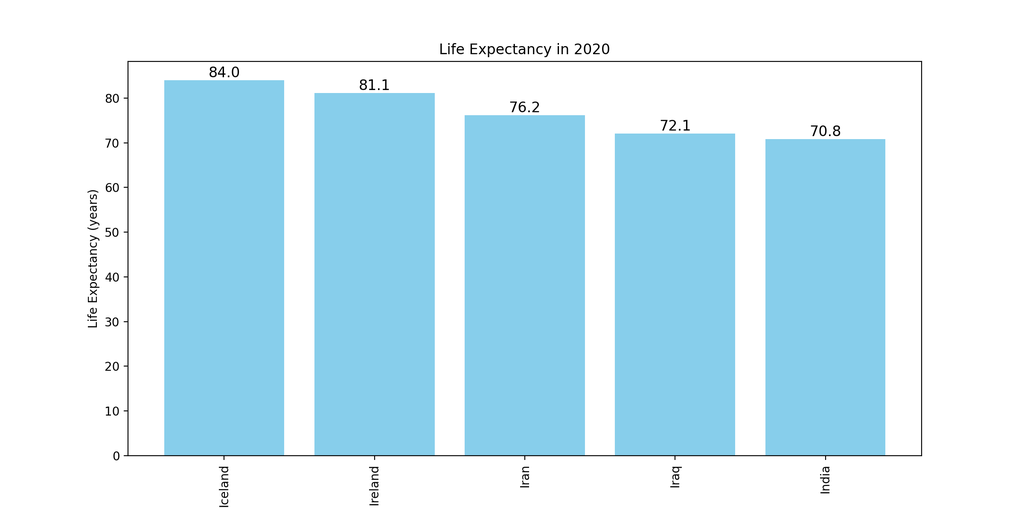

```python
# Select relevant data for 2020
data_2020 = subset_data[subset_data["Year"] == 2020]

# Sort the data for better readability (optional)
data_2020 = data_2020.sort_values(by="Life_expactancy", ascending=False)



# Create a bar plot
plt.figure(figsize=(12, 6))
plt.bar(data_2020["country"], data_2020["Life_expactancy"], color='skyblue')
plt.title("Life Expectancy in 2020")
plt.xlabel("Country")
plt.ylabel("Life Expectancy (years)")
plt.xticks(rotation=90)  # Rotate x-axis labels for better readability
for i, v in enumerate(data_2020['Life_expactancy']):
    plt.text(i, v, str(v), ha='center', va='bottom', fontsize=12)

plt.show()
```